# Desafio de Varejo

Paulo A Cressoni

October 19, 2017

## Agrupamento de Produtos

Antes de realizar o agrupamento dos produtos, vamos verificar se há dados faltando no nosso dataset. Abaixo podemos verificar que não há dados incompletos:

```
##         order_id             code         quantity            price
##                0                0                0                0
##       pis_cofins             icms tax_substitution         category
##                0                0                0                0
##      liquid_cost     order_status     capture_date     process_date
##                0                0                0                0
##   process_status   source_channel
##                0                0
```

O método mais eficaz para agrupar esses **dados mistos**, seria utilizar uma matriz de distância do tipo *Gower*, para então realizar os agrupamentos. Porém, como eu não tenho memória suficiente em minha máquina (devido à grande quantidade de dados), eu optei por normalizar os dados numéricos, e transformar os dados categóricos em *variáveis dummy*. Assim todas as variáveis estariam em um *range* entre 0 e 1, e então seria plausível utilizar distância euclideana para agrupar os dados.

Abaixo segue um gráfico que indica se há correlação entre as variáveis utilizadas, e sua força de acordo com a cor:

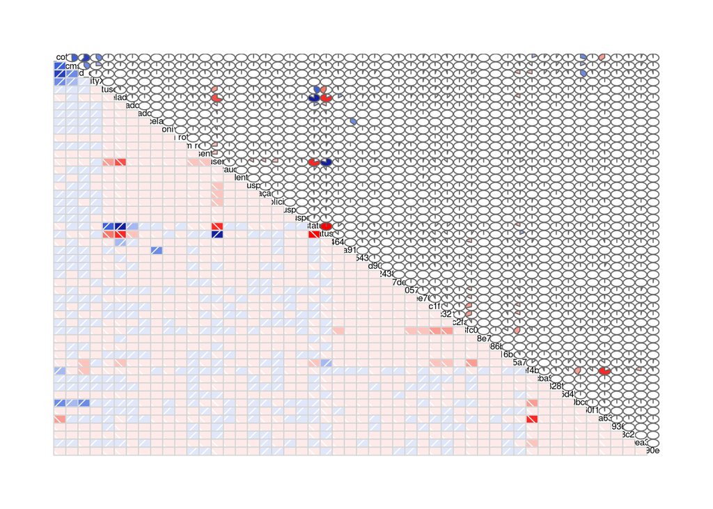

O método a ser utilizado para realizar o agrupamento de dados será o *K-means*. Este método divide os dados em *k* grupos, onde cada observação pertence ao grupo mais próximo da média. O gráfico abaixo mostra o valor de soma dos quadrados (neste caso da variância) para o agrupamento em até 15 *clusters*:

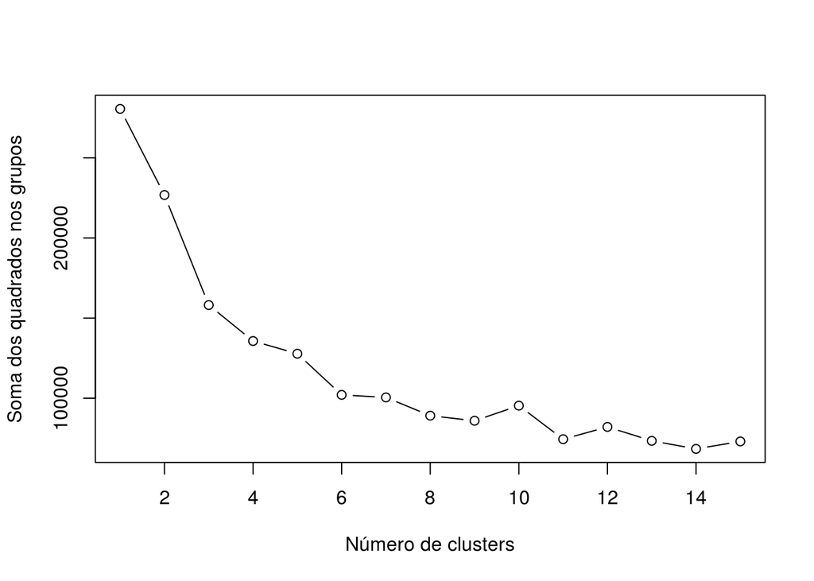

Podemos escolher o número de *clusters* de acordo com a curva no *formato de cotovelo* do gráfico. Vamos realizar o agrupamento em 4 *clusters*. Abaixo está o número do *cluster* com a quantidade de observações em cada *cluster*.

```
##
##     1     2     3     4
## 73861 60139 24706 20443
```

Após agrupados, os dados podem ser analisados de acordo com cada grupo. Abaixo está a análise do grupo 1:

```
##                              order_id
##  3e3225b6aec78dbdd8ce73773764a1b2:    5
##  050e40476e96a8781424e3a3def8fd9d:    4
##  3b9c261dc9286a0377b308e10abf53c8:    4
##  55f5b4656a0be00ea9b123370f3e5629:    4
##  00fd706e05e64cc25e734300e2f43486:    3
##  07833d4d641e6b10421f3ca74ca3a0f2:    3
##  (Other)                         :73838
##                                code          quantity
##  2e35421c34fb588ba40a0c57b3971d24: 9470   Min.   : 1.000
##  3454ea52396a4cfd3fc37414d30c7b9c: 4805   1st Qu.: 1.000
##  d57911cca4b08f7b46417d952c0ca1dc: 3661   Median : 1.000
##  32ceebf3efea1d04ace4183d20d4da5b: 3536   Mean   : 1.053
##  23056d85a1c9115cd021a6ad35c84aff: 3207   3rd Qu.: 1.000
##  0671c2b9132a3f5215a4212ce0691694: 3176   Max.   :70.000
##  (Other)                         :46006
##      price            pis_cofins           icms         tax_substitution
##  Min.   :    6.91   Min.   :   0.00   Min.   :   0.00   Min.   :  0.00
##  1st Qu.:  126.41   1st Qu.:  11.64   1st Qu.:   0.00   1st Qu.:  0.00
##  Median :  189.41   Median :  17.52   Median :  17.48   Median :  0.00
##  Mean   :  215.39   Mean   :  19.85   Mean   :  23.50   Mean   : 15.32
##  3rd Qu.:  299.91   3rd Qu.:  27.74   3rd Qu.:  37.88   3rd Qu.: 25.63
##  Max.   :19993.00   Max.   :1849.35   Max.   :3598.74   Max.   :280.52
##
##                              category      liquid_cost
##  388128822cef4b4f102ae881e040a64b:72907   Min.   :  4.114
##  90cc5bdd050bcd7cf0d50d079d0fda66:  410   1st Qu.: 64.932
##  61ad270def6d4b2403f4536f39cff29a:  191   Median :105.356
##  d7ecf0071e88c21e993da125d2229a51:  139   Mean   :121.403
##  98f679396a60f117b171ddedfcc3e5ed:  114   3rd Qu.:205.900
##  dda10a917a9ea3120e5d299af5105290:   45   Max.   :896.681
##  (Other)                         :   55
##                       order_status       capture_date       process_date
##  entrega total              :69260   2017-01-06: 1794   2017-01-06: 1294
##  solicitação de troca       : 1400   2016-11-25: 1535   2016-11-25: 1129
##  em rota de entrega         : 1375   2016-11-24:  846   2016-11-26:  938
##  entrega parcial            :  956   2017-01-07:  590   2017-01-07:  704
##  solicitação de cancelamento:  556   2016-11-26:  504   2016-11-24:  660
##  processado                 :  268   2017-03-15:  467   2017-01-10:  537
##  (Other)                    :   46   (Other)   :68125   (Other)   :68599
##     process_status                           source_channel  cluster
##  captado   :    0   fc7020775a7cdf161ab5267985c54601:29794   1:73861
##  processado:73861   a578e71c3216f513a84ec6a46084fd3a:13296   2:    0
##                     9d3e0fcbc1f16d80a76026e8f1c26002:11153   3:    0
##                     152bf0ce464047b9499ccb9e5b9b77a8: 4610   4:    0
##                     98defd6ee70dfb1dea416cecdf391f58: 4114
##                     ea2912716be1999ab62d5b9dfa4f58f9: 3007
##                     (Other)                         : 7887
##   capture_month   capture_year  process_month   process_year
##  maio    :10130   2016:34300   maio    :10099   2016:34246
##  janeiro : 9069   2017:39561   janeiro : 9065   2017:39614
##  novembro: 8273                novembro: 8324   NA's:    1
##  março   : 7721                março   : 7711
##  abril   : 7239                abril   : 7228
##  dezembro: 6633                (Other) :31433
##  (Other) :24796                NA's    :    1
```

Abaixo está a análise do grupo 2:

```
##                              order_id
##  a95921da5207ed69e7ef05fefb5ae415:    5
##  e0459fb2a1b29137204e07f3c57e4b95:    5
##  0a05f32038b22f199dedd5ad25ea923e:    4
##  357234b1c7280bed5bb1f69ab4d68e4a:    4
##  3c6633f3120eea9343ea96f7ce2f6cb7:    4
##  462903cd55e3153490e2b03cefd17c87:    4
##  (Other)                         :60113
##                                code          quantity
##  2e35421c34fb588ba40a0c57b3971d24: 9473   Min.   : 1.000
##  32ceebf3efea1d04ace4183d20d4da5b: 4328   1st Qu.: 1.000
##  3454ea52396a4cfd3fc37414d30c7b9c: 3185   Median : 1.000
##  5b7a30a9e6a43b170ad4d9e00d8d9359: 2756   Mean   : 1.045
##  760693745e10b0c5e68c42214c729b0d: 2337   3rd Qu.: 1.000
##  23056d85a1c9115cd021a6ad35c84aff: 2163   Max.   :10.000
##  (Other)                         :35897
##      price           pis_cofins          icms        tax_substitution
##  Min.   :  34.84   Min.   :  0.00   Min.   :  0.00   Min.   :  0.00
##  1st Qu.: 153.41   1st Qu.: 14.17   1st Qu.:  0.00   1st Qu.:  0.00
##  Median : 211.00   Median : 19.50   Median : 14.67   Median :  0.00
##  Mean   : 240.16   Mean   : 22.18   Mean   : 23.73   Mean   : 20.29
##  3rd Qu.: 324.40   3rd Qu.: 30.01   3rd Qu.: 44.98   3rd Qu.: 34.27
##  Max.   :2894.00   Max.   :267.69   Max.   :358.92   Max.   :158.61
##
##                              category      liquid_cost
##  388128822cef4b4f102ae881e040a64b:60139   Min.   : 27.28
##  4ece547755cba9e7fc14125bc895f31b:    0   1st Qu.: 81.61
##  568696c0b6828f77884ea8628fcc6200:    0   Median :116.63
##  61ad270def6d4b2403f4536f39cff29a:    0   Mean   :141.11
##  90cc5bdd050bcd7cf0d50d079d0fda66:    0   3rd Qu.:213.44
##  98f679396a60f117b171ddedfcc3e5ed:    0   Max.   :289.36
##  (Other)                         :    0
##                       order_status       capture_date       process_date
##  entrega total              :56110   2016-11-25: 2567   2016-11-25: 1689
##  entrega parcial            : 1374   2017-01-06: 2173   2017-01-06: 1406
##  em rota de entrega         :  938   2016-11-24:  990   2016-11-26: 1214
##  solicitação de troca       :  806   2016-09-13:  733   2017-01-07:  931
##  processado                 :  443   2017-01-07:  611   2016-11-24:  675
##  solicitação de cancelamento:  323   2016-07-13:  600   2017-01-10:  630
##  (Other)                    :  145   (Other)   :52465   (Other)   :53594
##     process_status                           source_channel  cluster
##  captado   :    0   b76eb9b8fc0f17098812da9117d3e500:60139   1:    0
##  processado:60139   152bf0ce464047b9499ccb9e5b9b77a8:    0   2:60139
##                     2934a86a91bfa55d7f20b4f08a441fac:    0   3:    0
##                     3ab2427543039f8c9f17d06f6f65a3a7:    0   4:    0
##                     5a97b8efd901c1d28ff86522b95babb9:    0
##                     5e38ada24380f6dc6094fbaac452b121:    0
##                     (Other)                         :    0
##   capture_month   capture_year  process_month   process_year
##  janeiro : 7757   2016:33233   janeiro : 7713   2016:33196
##  novembro: 7589   2017:26906   novembro: 7631   2017:26942
##  maio    : 5998                maio    : 5980   NA's:    1
##  março   : 5206                março   : 5214
##  julho   : 5182                julho   : 5174
##  setembro: 4799                (Other) :28426
##  (Other) :23608                NA's    :    1
```

Abaixo está a análise do grupo 3:

```
##                              order_id
##  273e916426bb720e1606cf6841bac2b5:    4
##  074d12fc9aa816d70c0cc3468918a779:    3
##  08a5872d99fb18c6a5241d279fa2dfd3:    3
##  100fe781c3ec3973737a3c91e1739cdb:    3
##  2424b8db2977eae3bd55e820da6c97c1:    3
##  40511bcb8097670a047d30f0492c4f7a:    3
##  (Other)                         :24687
##                                code          quantity
##  3454ea52396a4cfd3fc37414d30c7b9c: 2684   Min.   : 1.000
##  4534ea61b50410b3b6243e02b40c8cd1: 2326   1st Qu.: 1.000
##  2e35421c34fb588ba40a0c57b3971d24: 2001   Median : 1.000
##  0671c2b9132a3f5215a4212ce0691694: 1970   Mean   : 1.048
##  b08b7321c4db8f45a1a97a79d1e44dd8: 1180   3rd Qu.: 1.000
##  32ceebf3efea1d04ace4183d20d4da5b: 1025   Max.   :24.000
##  (Other)                         :13520
##      price            pis_cofins           icms         tax_substitution
##  Min.   :    1.03   Min.   :   0.00   Min.   :   0.00   Min.   :  0.00
##  1st Qu.:  161.91   1st Qu.:  11.55   1st Qu.:   0.00   1st Qu.:  0.00
##  Median :  189.90   Median :  17.52   Median :  27.79   Median :  0.00
##  Mean   :  236.45   Mean   :  19.35   Mean   :  27.13   Mean   : 16.38
##  3rd Qu.:  289.40   3rd Qu.:  26.34   3rd Qu.:  38.68   3rd Qu.: 30.05
##  Max.   :11420.96   Max.   :1056.44   Max.   :2055.77   Max.   :280.83
##
##                              category      liquid_cost
##  388128822cef4b4f102ae881e040a64b:20897   Min.   : 16.66
##  9a97178a18aa6333aabdfb21de182b99: 2560   1st Qu.:101.35
##  90cc5bdd050bcd7cf0d50d079d0fda66:  953   Median :117.08
##  dda10a917a9ea3120e5d299af5105290:  200   Mean   :139.82
##  98f679396a60f117b171ddedfcc3e5ed:   58   3rd Qu.:191.26
##  568696c0b6828f77884ea8628fcc6200:   15   Max.   :896.68
##  (Other)                         :   23
##                       order_status       capture_date       process_date
##  cancelado boleto não pago  :18425   2017-01-06:  782   0000-00-00:24491
##  cancelado                  : 5274   2016-11-25:  733   2017-05-14:    5
##  cancelado dados divergentes:  674   2016-11-24:  496   2017-03-11:    4
##  fraude confirmada          :  163   2017-01-07:  248   2017-05-08:    4
##  cancelado fraude confirmada:   75   2016-09-13:  243   2016-08-08:    3
##  suspenso barragem          :   32   2017-05-05:  219   2016-08-23:    3
##  (Other)                    :   63   (Other)   :21985   (Other)   :  196
##     process_status                           source_channel cluster
##  captado   :24706   b76eb9b8fc0f17098812da9117d3e500:9397   1:    0
##  processado:    0   a578e71c3216f513a84ec6a46084fd3a:5026   2:    0
##                     9d3e0fcbc1f16d80a76026e8f1c26002:4413   3:24706
##                     152bf0ce464047b9499ccb9e5b9b77a8:2373   4:    0
##                     7261d300057219056592010c7bdaf5ee:1087
##                     fc7020775a7cdf161ab5267985c54601: 695
##                     (Other)                         :1715
##   capture_month  capture_year  process_month   process_year
##  novembro:2978   2016:12098   março   :   33   2016:   95
##  maio    :2904   2017:12608   maio    :   28   2017:  120
##  janeiro :2857                abril   :   24   NA's:24491
##  março   :2808                dezembro:   20
##  abril   :2239                janeiro :   20
##  dezembro:2041                (Other) :   90
##  (Other) :8879                NA's    :24491
```

Abaixo está a análise do grupo 4:

```
##                              order_id
##  18d694b101ff2f002bdb9ad0e0a4bf64:    2
##  3ba65b84db8582d06cf411b282de89e4:    2
##  62c9cf0a3d06f588e407b3c862b2a03d:    2
##  87ec2e8b786aee246ae1aca41860e929:    2
##  a4aabce70761bb496483ae9eb84693d5:    2
##  be3c7f387f9a3052d8212be15143dc4e:    2
##  (Other)                         :20431
##                                code          quantity
##  4534ea61b50410b3b6243e02b40c8cd1:14899   Min.   :  1.000
##  55447a73ff140176f4210347854c71f1:  902   1st Qu.:  1.000
##  a586c072b4a3958ac72a6fff71730cb3:  833   Median :  1.000
##  7e3713530b46887cff58a2e2ac433ac5:  805   Mean   :  1.104
##  547bbdaa191bdb83d5b5b376bf2402fb:  721   3rd Qu.:  1.000
##  dd1935ffd0ee2b6ec159ba7867d11e57:  679   Max.   :100.000
##  (Other)                         : 1604
##      price           pis_cofins          icms         tax_substitution
##  Min.   :    7.9   Min.   :  0.00   Min.   :   0.00   Min.   :  0.00
##  1st Qu.:  174.9   1st Qu.:  0.00   1st Qu.:   0.00   1st Qu.:  0.00
##  Median :  188.1   Median :  0.00   Median :  30.76   Median :  0.00
##  Mean   :  285.8   Mean   : 10.77   Mean   :  32.43   Mean   : 21.79
##  3rd Qu.:  217.8   3rd Qu.:  0.00   3rd Qu.:  35.08   3rd Qu.: 47.44
##  Max.   :16140.0   Max.   :735.38   Max.   :1053.32   Max.   :280.62
##
##                              category      liquid_cost
##  9a97178a18aa6333aabdfb21de182b99:15449   Min.   :  4.114
##  90cc5bdd050bcd7cf0d50d079d0fda66: 3845   1st Qu.:119.507
##  dda10a917a9ea3120e5d299af5105290:  808   Median :119.507
##  98f679396a60f117b171ddedfcc3e5ed:  158   Mean   :169.391
##  568696c0b6828f77884ea8628fcc6200:   55   3rd Qu.:119.507
##  4ece547755cba9e7fc14125bc895f31b:   45   Max.   :896.681
##  (Other)                         :   83
##                       order_status       capture_date       process_date
##  entrega total              :19375   2016-11-25:  730   2016-11-25:  506
##  em rota de entrega         :  336   2016-11-24:  194   2016-11-26:  249
##  solicitação de troca       :  194   2017-01-06:  160   2016-12-06:  160
##  entrega parcial            :  186   2016-12-05:  146   2016-11-24:  147
##  processado                 :  177   2017-02-01:  137   2017-01-10:  144
##  solicitação de cancelamento:  143   2017-02-02:  137   2016-11-29:  141
##  (Other)                    :   32   (Other)   :18939   (Other)   :19096
##     process_status                           source_channel  cluster
##  captado   :    0   b76eb9b8fc0f17098812da9117d3e500:12301   1:    0
##  processado:20443   a578e71c3216f513a84ec6a46084fd3a: 2408   2:    0
##                     9d3e0fcbc1f16d80a76026e8f1c26002: 2148   3:    0
##                     fc7020775a7cdf161ab5267985c54601:  750   4:20443
##                     7261d300057219056592010c7bdaf5ee:  609
##                     5a97b8efd901c1d28ff86522b95babb9:  604
##                     (Other)                         : 1623
##    capture_month  capture_year   process_month  process_year
##  novembro :2500   2016:12142   novembro :2491   2016:12123
##  dezembro :2248   2017: 8301   dezembro :2274   2017: 8320
##  janeiro  :2036                janeiro  :2023
##  maio     :1901                maio     :1900
##  agosto   :1779                agosto   :1773
##  fevereiro:1647                fevereiro:1665
##  (Other)  :8332                (Other)  :8317
```

Nos gráficos abaixo, cada barra representa um *cluster*, o eixo *y* representa a quantidade de observações e na legenda, neste caso, temos a variável *order_status*. Podemos verificar que há um *cluster* que agrupa uma grande quantidade de observações referentes à cancelamentos diversos e fraudes.

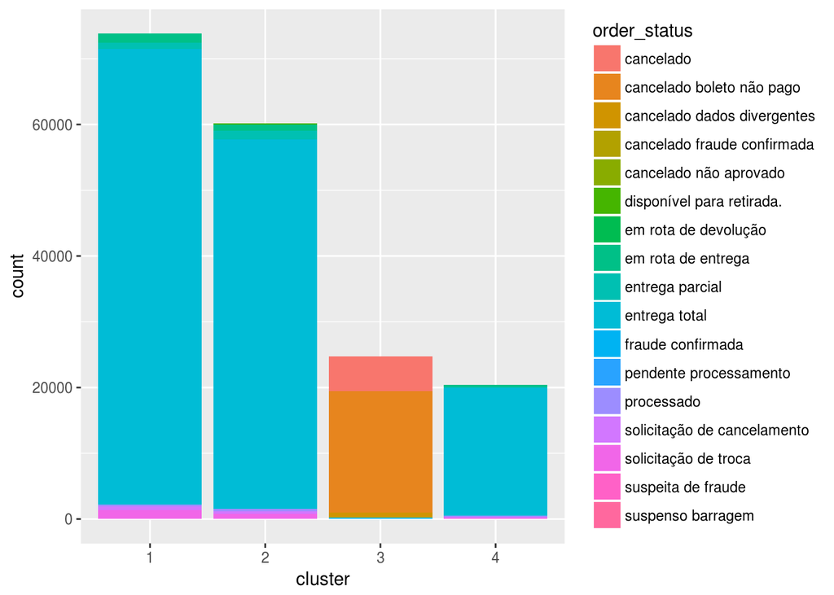

No gráfico abaixo temos um gráfico similar, porém na legenda temos a variável *process_status*. Podemos observar que o *cluster* que contém apenas o valor *captado* é o mesmo anteriormente citado acima:

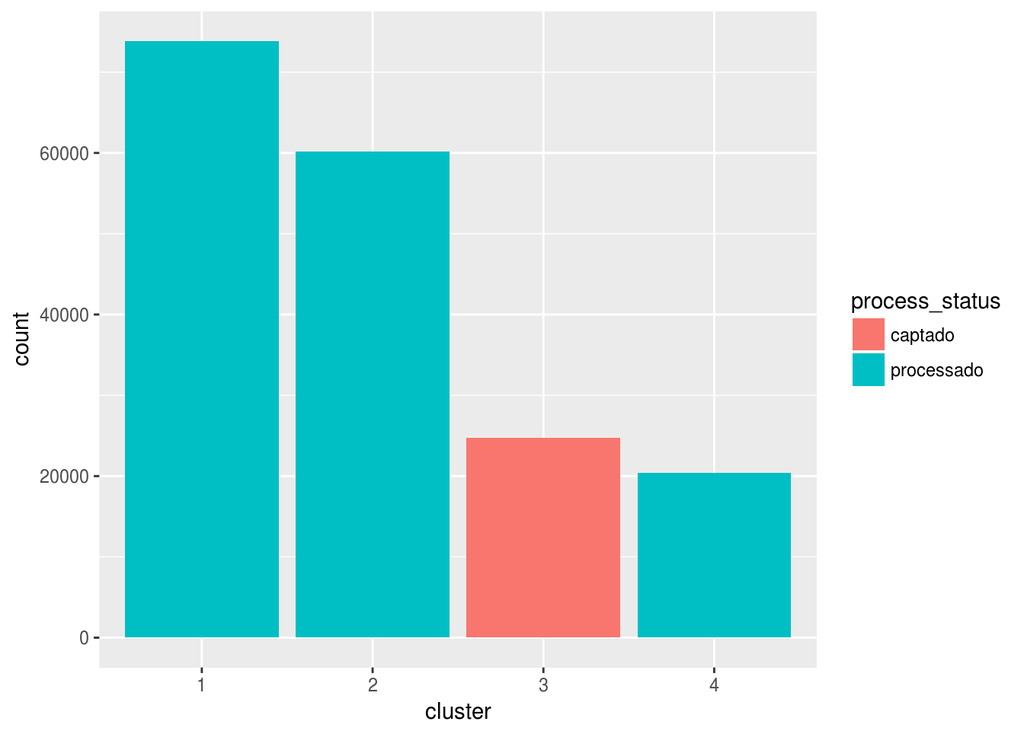

Abaixo podemos ver o gráfico com a legenda representando a variável *category*. Podemos observar que há um *cluster* que se difere dos outros por ter a maioria de seus produtos referentes a uma categoria pouco presente nos outros *clusters*:

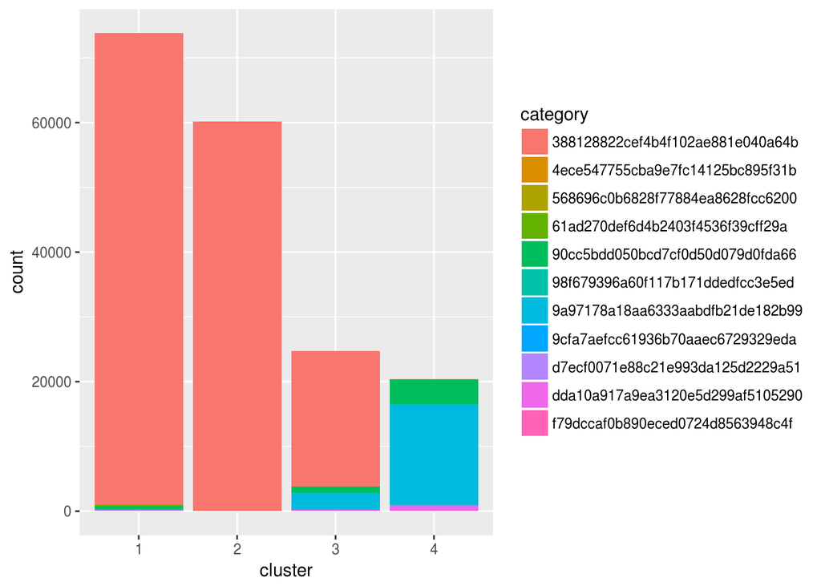

No gráfico abaixo a legenda representa a variável *source_channel*. Podemos observar que há um outro *cluster* com uma grande quantidade de um *source_channel* especícifo:

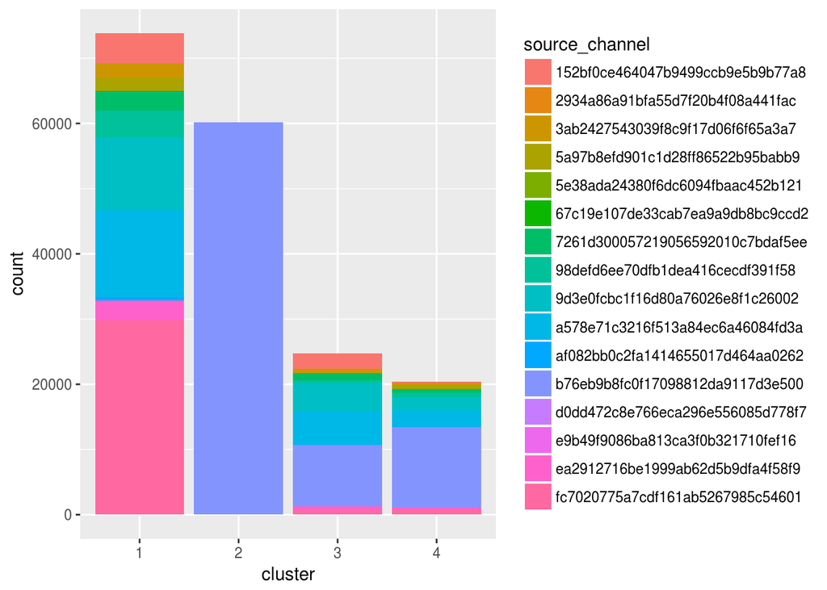

Podemos verificar abaixo que há um *cluster* com sua maioria composta de apenas um *code* específico:

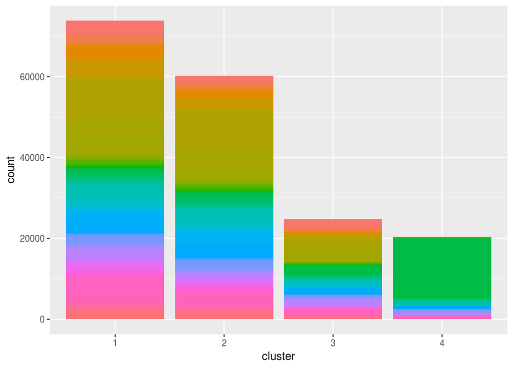

Abaixo podemos observar que dentro dos *clusters* o process_month (mês da variável process_date) é bem distribuído e com apenas algumas poucas oscilações, exceto no *cluster* onde há muitos cancelamentos e fraudes.

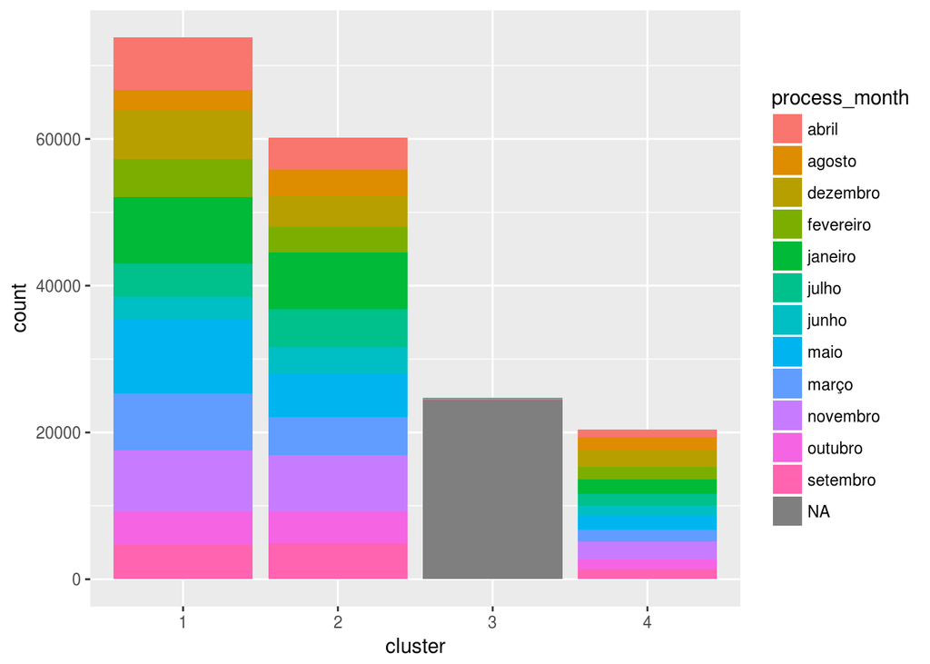

## Considerações Finais

Na Análise acima pode-se ter uma noção de como agrupar os produtos. Após agrupados, os grupos podem ser analisados e são encontradas algumas similaridades nos mesmos. Para uma análise mais profunda seria aconselhável a presença de um profissional com a inteligência do negócio. Como muitas dados estão codificados, a análise acaba sendo limitada. A análise pode ser realizada utilizando outros métodos, porém por motivo de hardware (memória insuficiente) este foi o método optado.